# Baseball

Alan T. Arnholt

Create the data set discussed on page 248 of [*OpenIntro Statistics*](https://drive.google.com/file/d/0B-DHaDEbiOGkc1RycUtIcUtIelE/view).

```r
library(dplyr)
library(openintro)
bat10 <- mlbBat10 %>%
  filter(AB > 200)
# Note unused factor levels
table(bat10$position)
```

```
 1B  2B  3B  OF  SS  DH   C   P   -
 33  39  40 120  42  14  39   0   0
```

```r
bat10$position <- droplevels(bat10$position)
table(bat10$position)
```

```
 1B  2B  3B  OF  SS  DH   C
 33  39  40 120  42  14  39
```

```r
# Combine 1B, 2B, 3B, SS into infield (IF)
#
bat10$pos <- plyr::revalue(bat10$position,
                       replace = c("1B" = "IF", "2B" = "IF", "3B" = "IF", "SS" = "IF"))
table(bat10$pos)
```

```
 IF  OF  DH   C
154 120  14  39
```

```r
# Note must detach plyr for dplyr to work properly
# detach("package:plyr", unload = TRUE)
```

Create the summary statistics presented in Table 5.24 of [*OpenIntro Statistics*](https://drive.google.com/file/d/0B-DHaDEbiOGkc1RycUtIcUtIelE/view).

```r
T524 <- bat10 %>%
  group_by(pos) %>%
  summarise(n = n(), Mean = round(mean(OBP), 4), SD = round(sd(OBP), 4))
T524
```

```
# A tibble: 4 x 4
     pos     n   Mean     SD
  <fctr> <int>  <dbl>  <dbl>
1     IF   154 0.3315 0.0371
2     OF   120 0.3342 0.0294
3     DH    14 0.3478 0.0360
4      C    39 0.3226 0.0451
```

```r
DT::datatable(T524)
```

|  | pos | n | Mean | SD |
| --- | --- | --- | --- | --- |
| 1 | IF | 154 | 0.3315 | 0.0371 |
| 2 | OF | 120 | 0.3342 | 0.0294 |
| 3 | DH | 14 | 0.3478 | 0.036 |
| 4 | C | 39 | 0.3226 | 0.0451 |

## Hypotheses

**Your Turn:**

1. Write the null and alternative hypotheses to test whether the on base percentage is related to position.

$H_0:$

$H_A:$

2. List the conditions necessary for performing ANOVA:

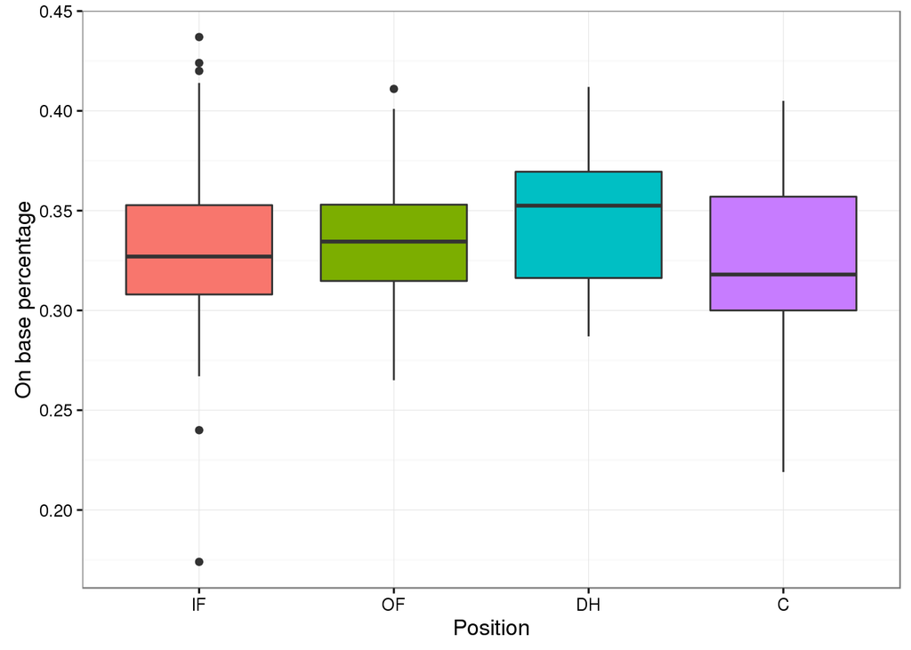

Figure 1: Side-by-side boxplots of on base percentage according to position

```r
library(ggplot2)
ggplot(data = bat10, aes(x = pos, y = OBP, fill = pos)) +
  geom_boxplot() +
  theme_bw() +
  labs(y = "On base percentage", x = "Position") +
  guides(fill = FALSE)
```

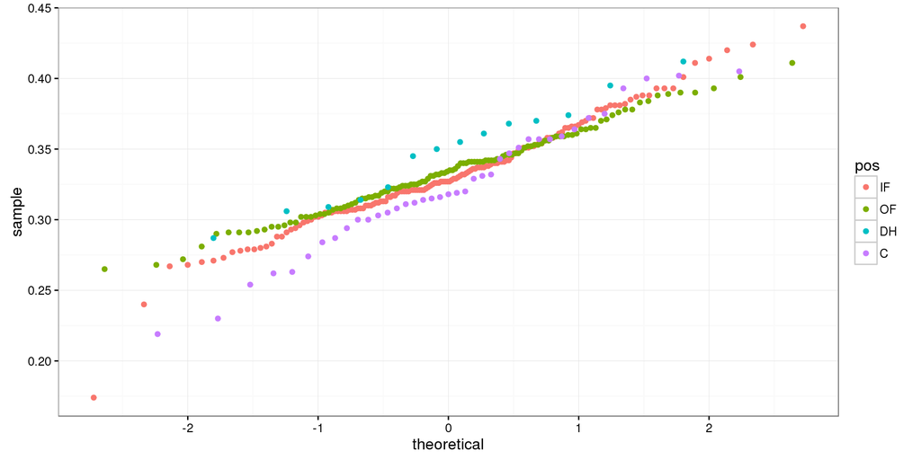

```r
ggplot(data = bat10, aes(sample = OBP, color = pos)) +
  stat_qq() +
  theme_bw()
```

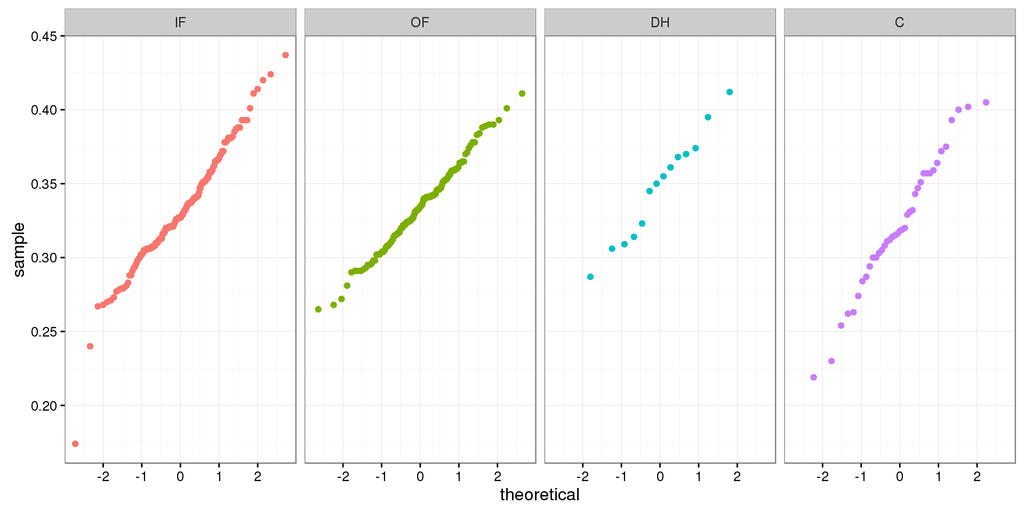

```r
ggplot(data = bat10, aes(sample = OBP, color = pos)) +
  stat_qq() +
  facet_grid(.~pos) +
  theme_bw() +
  guides(color = FALSE)
```

```r
mod.aov <- aov(OBP ~ pos, data = bat10)
summary(mod.aov)
```

```
             Df Sum Sq  Mean Sq F value Pr(>F)
pos           3 0.0076 0.002519   1.994  0.115
Residuals   323 0.4080 0.001263
```

**Your turn:** Compute the $p-$value using `pf`. Does your answer agree with the output from the ANOVA table?

```r
pf(1.994, 3, 323, lower = FALSE)
```

```
[1] 0.1147443
```

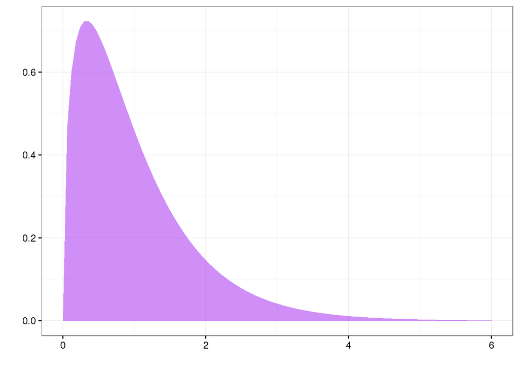

```r
library(ggplot2)
ggplot(data = data.frame(x = seq(0, 6, length= 200)), aes(x = x)) +
  stat_function(fun = df, args = list(3, 233), geom = "area", fill = "purple", alpha = 0.5) +
  theme_bw() +
  labs(x = "", y = "")
```

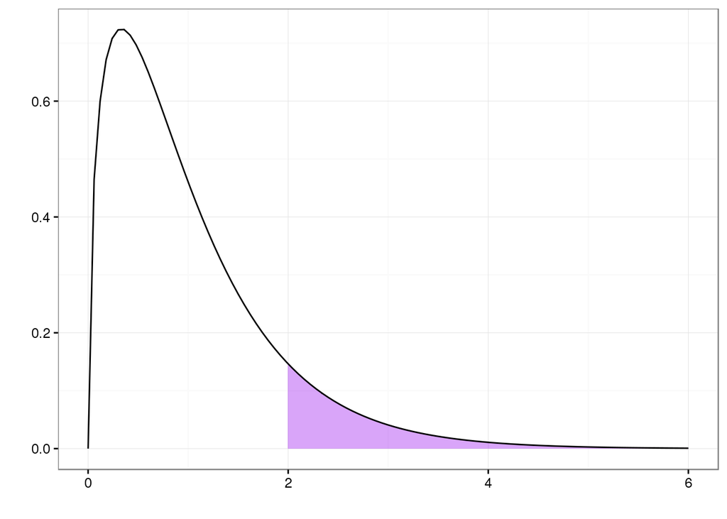

```r
df_limit <- function(x){
  y <- df(x, 3, 323)
  y[x < 1.994] <- NA
  return(y)
}
p <- ggplot(data.frame(x = c(0, 6)), aes(x = x))
p + stat_function(fun = df_limit, geom = "area", fill = "purple", alpha = 0.4, n = 500) +
  stat_function(fun = df, args = list(3, 323)) +
  theme_bw() +
  labs(x = "", y = "")
```

**Finished - Now consider a different problem.**

Use `bat10` to test whether the on base percentage is related to position.

```r
T5N <- bat10 %>%
  group_by(position) %>%
  summarise(n = n(), Mean = round(mean(OBP), 4), SD = round(sd(OBP), 4))
T5N
```

```
# A tibble: 7 x 4
  position     n   Mean     SD
    <fctr> <int>  <dbl>  <dbl>
1       1B    33 0.3554 0.0419
2       2B    39 0.3348 0.0278
3       3B    40 0.3224 0.0402
4       OF   120 0.3342 0.0294
5       SS    42 0.3184 0.0279
6       DH    14 0.3478 0.0360
7        C    39 0.3226 0.0451
```

**Your turn:**

1. Write the null and alternative hypotheses to test whether the on base percentage is related to position.

$H_O:$

$H_A:$

2. List the conditions necessary for performing ANOVA:

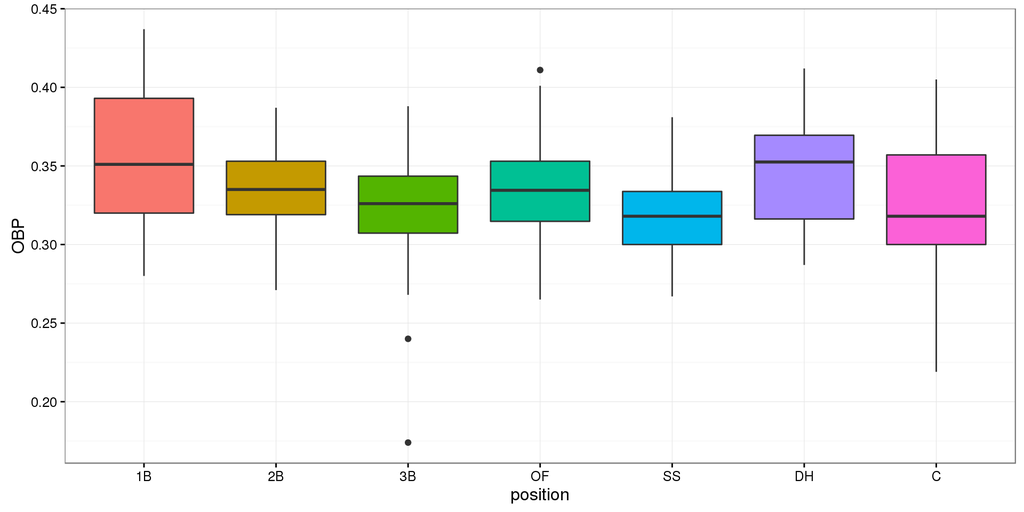

```r
ggplot(data = bat10, aes(x = position, y = OBP, fill = position)) +
  geom_boxplot() +
  theme_bw() +
  guides(fill = FALSE)
```

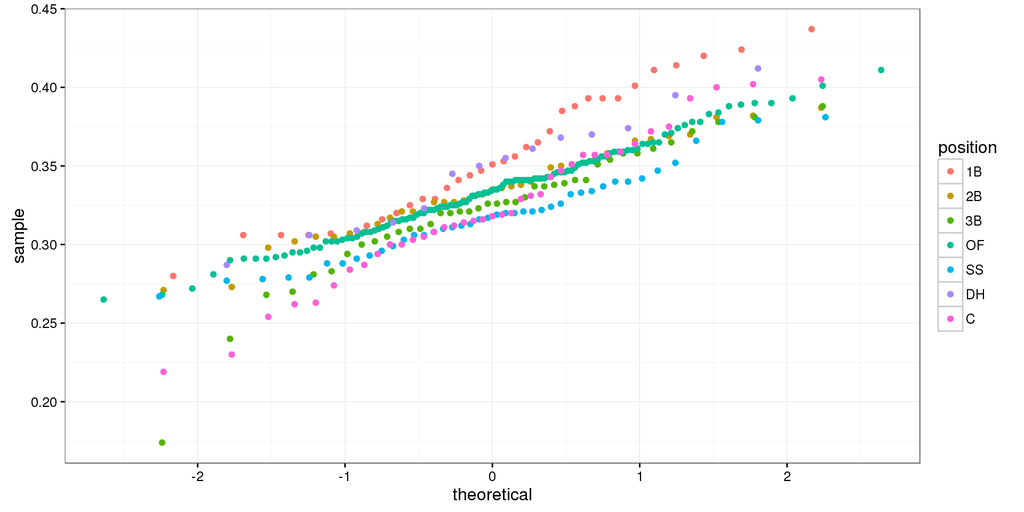

```r
ggplot(data = bat10, aes(sample = OBP, color = position)) +
  stat_qq() +
  theme_bw()
```

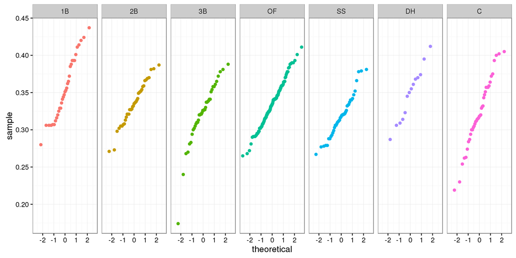

```r
ggplot(data = bat10, aes(sample = OBP, color = position)) +
  stat_qq() +
  facet_grid(.~position) +
  theme_bw() +
  guides(color = FALSE)
```

```r
mod2.aov <- aov(OBP ~ position, data = bat10)
summary(mod2.aov)
```

```
             Df Sum Sq  Mean Sq F value   Pr(>F)
position      6 0.0374 0.006233   5.275 3.35e-05 ***
Residuals   320 0.3781 0.001182
---
Signif. codes:  0 '***' 0.001 '**' 0.01 '*' 0.05 '.' 0.1 ' ' 1
```

**Your turn:**

1. Do you reject the null hypothesis? If so, what does this mean in plain English?
2. Which positions have a higher on base percentage?

## Bonferroni Method

$$CI_{1 - \alpha_e}(\mu_i - \mu_j) = (\bar{Y}_{i\bullet} - \bar{Y}_{j\bullet}) \pm t_{1 - \tfrac{\alpha_c}{2K};df_{Error}}\sqrt{MS_{Error}}\sqrt{\frac{1}{n_i} + \frac{1}{n_j}}$$

```r
T5N
```

```
# A tibble: 7 x 4
  position     n   Mean     SD
    <fctr> <int>  <dbl>  <dbl>
1       1B    33 0.3554 0.0419
2       2B    39 0.3348 0.0278
3       3B    40 0.3224 0.0402
4       OF   120 0.3342 0.0294
5       SS    42 0.3184 0.0279
6       DH    14 0.3478 0.0360
7        C    39 0.3226 0.0451
```

```r
(0.3554 - 0.3348) +c(-1, 1)*qt(1 - 0.05/(2*choose(7,2)), 320)*sqrt(0.001182)*sqrt(1/33 + 1/39)
```

```
[1] -0.004303859  0.045503859
```

**Your Turn:**

Find a 95% Bonferroni CI for the $\mu_{3B} - \mu_{1B}$

```r
# Your code here
```

Another approach is to use `pairwise.t.test()`

```r
pairwise.t.test(bat10$OBP, bat10$position, p.adj = "bonferroni")
```

```
    Pairwise comparisons using t tests with pooled SD

data:  bat10$OBP and bat10$position

   1B      2B      3B      OF      SS      DH
2B 0.24462 -       -       -       -       -
3B 0.00120 1.00000 -       -       -       -
OF 0.03961 1.00000 1.00000 -       -       -
SS 0.00011 0.67785 1.00000 0.21761 -       -
DH 1.00000 1.00000 0.38248 1.00000 0.12310 -
C  0.00143 1.00000 1.00000 1.00000 1.00000 0.40683

P value adjustment method: bonferroni
```

## Tukey’s Honestly Significant Difference (HSD)

$$CI_{1 - \alpha_e}(\mu_i - \mu_j) = (\bar{Y}_{i\bullet} - \bar{Y}_{j\bullet}) \pm \frac{q_{1 - \alpha_e:a, \nu}}{\sqrt{2}}\sqrt{MS_{Error}}\sqrt{\frac{1}{n_i} + \frac{1}{n_j}}$$
Note: $a=$ the number of treatments, $\nu=$ the degrees of freedom for $MS_{Error}$. The notation $q_{1 - \alpha;a,\nu}$ denotes the studentized range value with $1 - \alpha$ area to the left with $a$ and $\nu$ degrees of freedom, respectively. For example, $q_{0.95;4,20} = 3.9582935$ is obtained by entering:

```r
qtukey(0.95, 4, 20)
```

```
[1] 3.958293
```

**Your Turn:**

Verify using the formula that $CI_{0.95}(\mu_{3B} - \mu_{1B}) = [-0.05696, -0.00899]$.

```r
# Your code here
```

```r
TukeyHSD(mod2.aov)
```

```
  Tukey multiple comparisons of means
    95% family-wise confidence level

Fit: aov(formula = OBP ~ position, data = bat10)

$position
               diff          lwr          upr     p adj
2B-1B -0.0206293706 -0.044754902  0.003496161 0.1496557
3B-1B -0.0329742424 -0.056961156 -0.008987328 0.0011118
OF-1B -0.0211742424 -0.041223488 -0.001124997 0.0307855
SS-1B -0.0370670996 -0.060794433 -0.013339766 0.0001053
DH-1B -0.0076385281 -0.040171808  0.024894752 0.9927262
C-1B  -0.0328088578 -0.056934389 -0.008683326 0.0013225
3B-2B -0.0123448718 -0.035298490  0.010608747 0.6851503
OF-2B -0.0005448718 -0.019345638  0.018255894 1.0000000
SS-2B -0.0164377289 -0.039119944  0.006244487 0.3259316
DH-2B  0.0129908425 -0.018788253  0.044769938 0.8888576
C-2B  -0.0121794872 -0.035277925  0.010918951 0.7050406
OF-3B  0.0118000000 -0.006822556  0.030422556 0.4950415
SS-3B -0.0040928571 -0.026627579  0.018441864 0.9982356
DH-3B  0.0253357143 -0.006338276  0.057009705 0.2133531
C-3B   0.0001653846 -0.022788234  0.023119003 1.0000000
SS-OF -0.0158928571 -0.034179844  0.002394130 0.1360106
DH-OF  0.0135357143 -0.015271262  0.042342690 0.8047266
C-OF  -0.0116346154 -0.030435382  0.007166151 0.5245490
DH-SS  0.0294285714 -0.002049293  0.060906436 0.0842020
C-SS   0.0042582418 -0.018423974  0.026940457 0.9978753
C-DH  -0.0251703297 -0.056949425  0.006608765 0.2237267
```

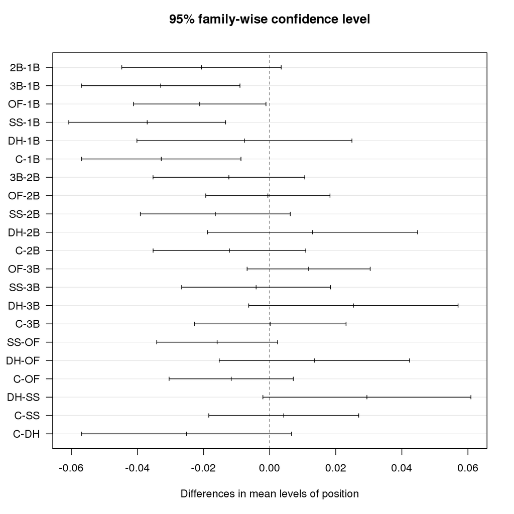

```r
par(las = 1)
plot(TukeyHSD(mod2.aov))
```

```r
par(las = 0)
```

## Confidence Intervals (2 Groups)

```r
NDF <- bat10 %>%
  filter(team == "BAL" | team == "BOS") %>%
  select(OBP, team)
NDF %>%
  group_by(team) %>%
  summarize(Mean = mean(OBP), SD = sd(OBP), n = n())
```

```
# A tibble: 2 x 4
    team      Mean         SD     n
  <fctr>     <dbl>      <dbl> <int>
1    BAL 0.3228182 0.02947819    11
2    BOS 0.3497000 0.03019584    10
```

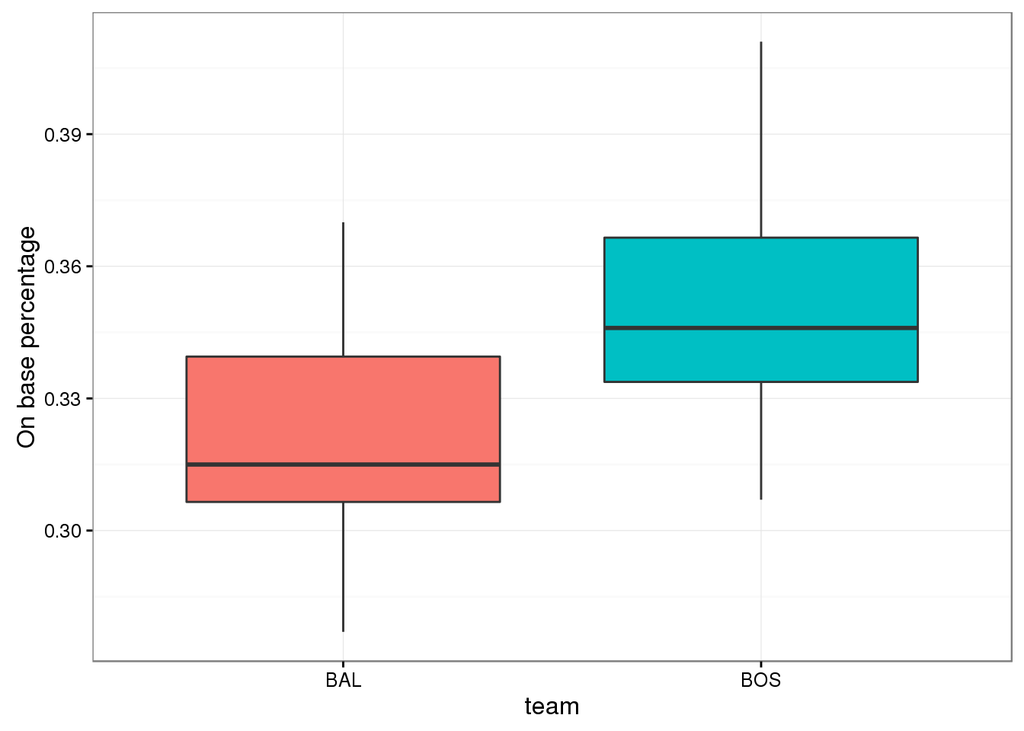

```r
ggplot(data = NDF, aes(x = team, y = OBP, fill = team)) +
  geom_boxplot() +
  theme_bw() +
  labs(y = "On base percentage") +
  guides(fill = FALSE)
```

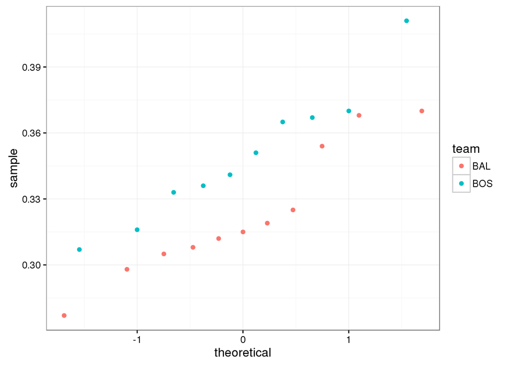

```r
ggplot(data = NDF, aes(sample = OBP, color = team)) +
  stat_qq() +
  theme_bw()
```

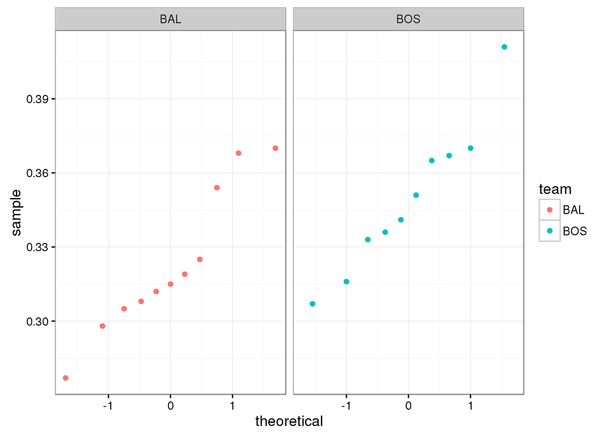

```r
# Or
ggplot(data = NDF, aes(sample = OBP, color = team)) +
  stat_qq() +
  theme_bw() +
  facet_grid(. ~ team)
```

```r
# Standard 90% CI first
t.test(OBP ~ team, data = NDF, conf.level = 0.90)
```

```
    Welch Two Sample t-test

data:  OBP by team
t = -2.0607, df = 18.71, p-value = 0.05351
alternative hypothesis: true difference in means is not equal to 0
90 percent confidence interval:
 -0.049456471 -0.004307166
sample estimates:
mean in group BAL mean in group BOS
        0.3228182         0.3497000
```

```r
df <- t.test(OBP ~ team, data = NDF, conf.level = 0.90)$parameter
df
```

```
      df
18.71049
```

## Bootstrap

For more on the bootstrap method see http://stat-ata-asu.github.io/STT3851ClassRepo/Rmarkdown/TheBootstrap.html.

```r
BALOBP <- bat10$OBP[bat10$team == "BAL"]
BOSOBP <- bat10$OBP[bat10$team == "BOS"]
obsdiff <- mean(BALOBP) - mean(BOSOBP)
obsdiff
```

```
[1] -0.02688182
```

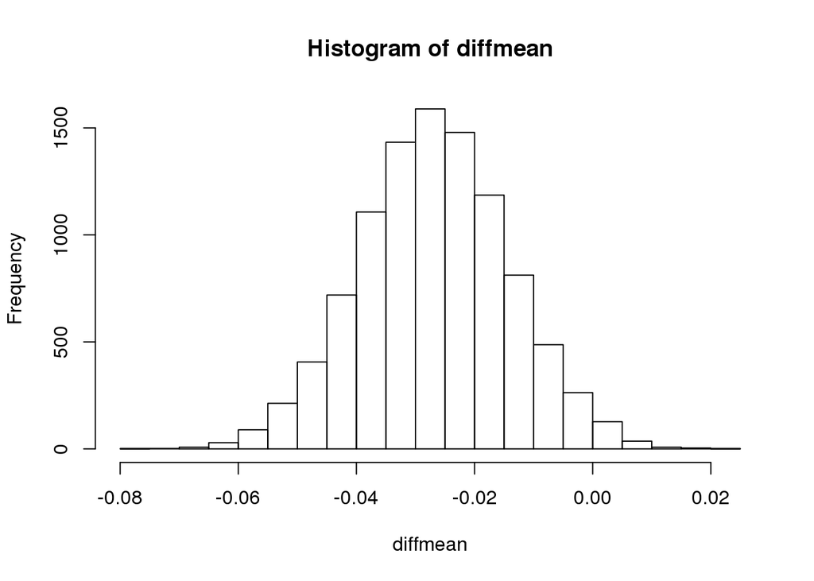

```r
SIMS <- 10^4 - 1
diffmean <- numeric(SIMS)
for(i in 1:SIMS){
  sampBAL <- sample(BALOBP, size = sum(!is.na(BALOBP)), replace = TRUE)
  sampBOS <- sample(BOSOBP, size = sum(!is.na(BOSOBP)), replace = TRUE)
  diffmean[i] <- mean(sampBAL) - mean(sampBOS)
}
hist(diffmean)
```

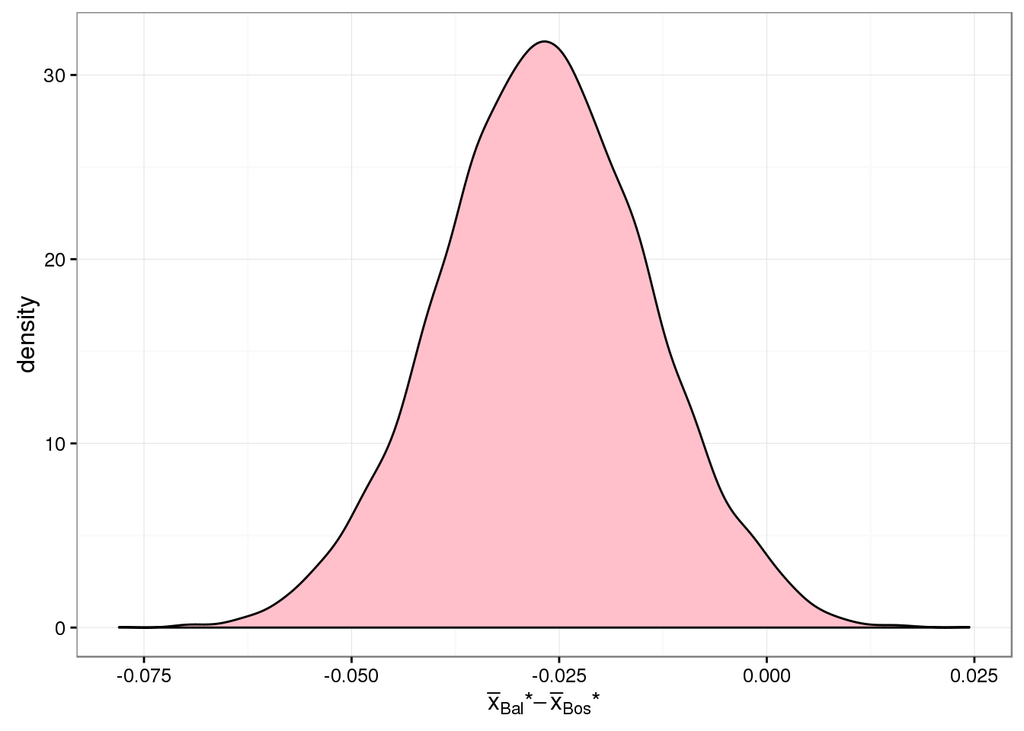

```r
# OR
ggplot(data = data.frame(x = diffmean), aes(x = x)) +
  geom_density(fill = "pink") +
  theme_bw() +
  labs(x = substitute(paste(bar(x)[Bal],"*", - bar(x)[Bos],"*")))
```

## Percentile Approach

```r
BSCI <- quantile(diffmean, probs = c(0.05, 0.95))
BSCI
```

```
         5%         95%
-0.04776364 -0.00579000
```

## Standard Bootstrap

```r
SBS <- obsdiff + c(-1, 1)*qt(0.95, df)*sd(diffmean)
SBS
```

```
[1] -0.048726458 -0.005037179
```